# Структура научной презентации

Кулябов Д. С.

Российский университет дружбы народов, Москва, Россия

Объединённый институт ядерных исследований, Дубна, Россия

# Информация

## Докладчик

- Казначеев Сергей Ильич
- Студент
- Российский университет дружбы народов
- [1132240693@pfur.ru]

[figure not shown]

## Цель

Получение навыков правильной работы с репозиториями git.

## Задачи

Выполнить работу для тестового репозитория. Преобразовать рабочий репозиторий в репозиторий с git-flow и conventional commits.

## Установка ПО

Для начала подключим репозиторий из которого можно скачать gitflow

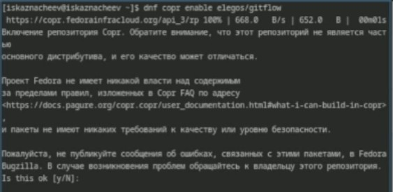

sc1

## Установка ПО

После установим gitflow

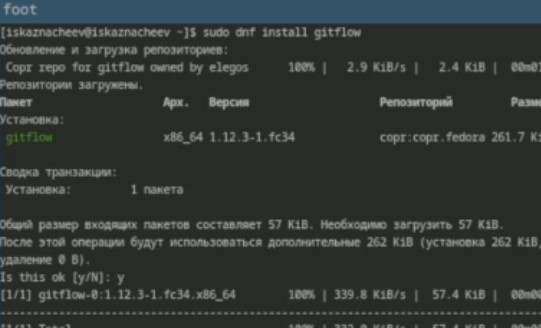

sc2

## Установка ПО

Теперь установим Nodejs

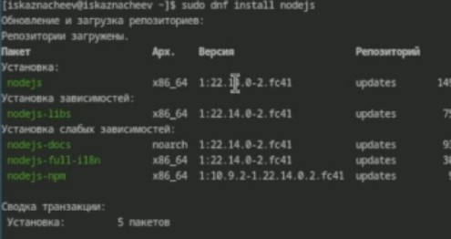

sc3

## Установка ПО

Установим pnpm

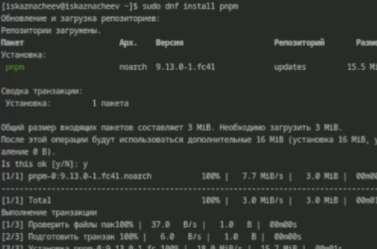

sc4

## Установка ПО

Запустим pnpm

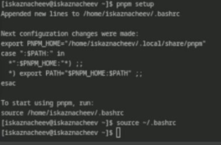

sc5

## Установка ПО

Теперь установим с помощью него Commitizien

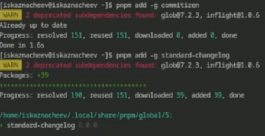

sc6

## Настройка репозитория

Создаем тестовый репозиторий git-extended

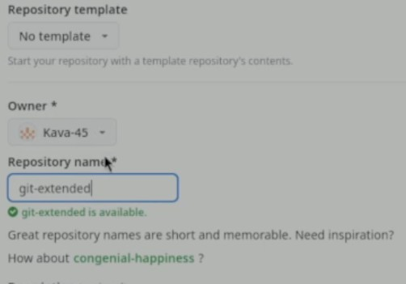

sc7

## Настройка репозитория

И клонируем его себе на компьютер

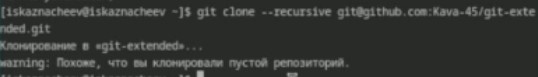

sc8

## Настройка репозитория

Создадим какой нибудь файл и проиндексируем его с помощью git add сделав при этом commit

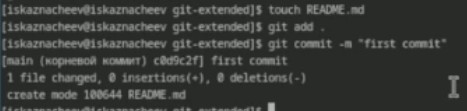

sc9

## Настройка репозитория

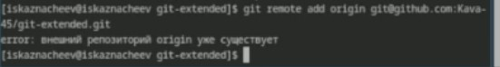

sc10

## Cоздание коммитов

Теперь проинициализируем pnpm

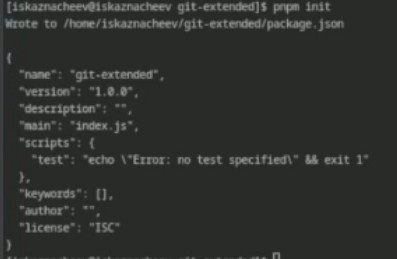

sc12

## Cоздание коммитов

После инициальзации создается файл packege.json который меняем следующим образом

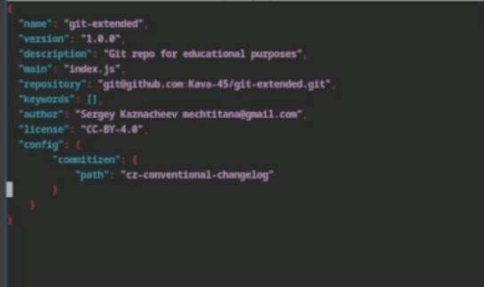

sc13

## Cоздание коммитов

Делаем коммит с помощью cz

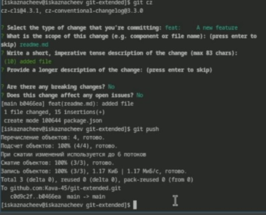

sc14

## Использование gitflow

Проинициализируем gitflow. Укажем название веток и префикс для версий

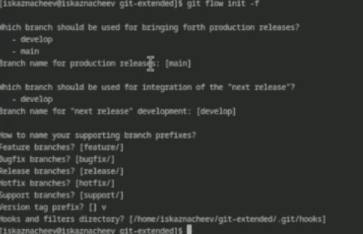

sc15

## Использование gitflow

Выведем список веток и убедимся, что мы находимся в develop, и запушим изменения на сервер

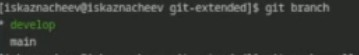

sc16

## Использование gitflow

Переключимся на ветку develop после чего создадим ветку релиза где создадим changelog

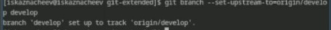

sc17

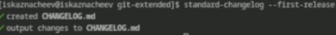

sc18

## Использование gitflow

Проиндексируем changelog и сделаем коммит

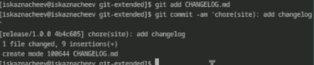

sc19

## Использование gitflow

[figure not shown]

sc21

## Использование gitflow

Загружаем данные на github

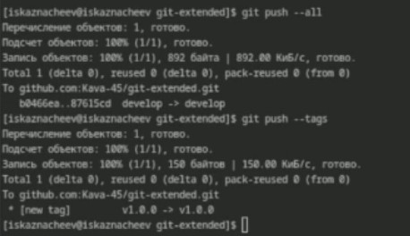

sc22

## Использование gitflow

Создаем релиз из changelog’a

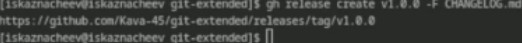

sc23

## Работа с релизами

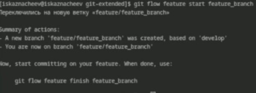

sc24

## Работа с релизами

Создаем ветку релиза

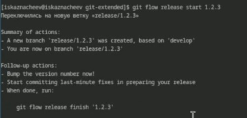

sc25

## Работа с релизами

Меняем версию в packege.json

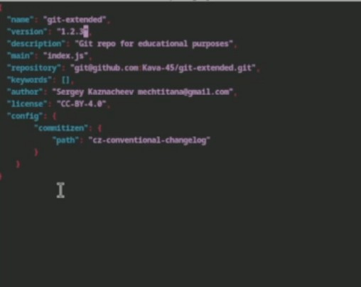

sc26

## Работа с релизами

Создаем ветку журнал изменений, проиндексируем его и сольем ветку с ним в ветку develop

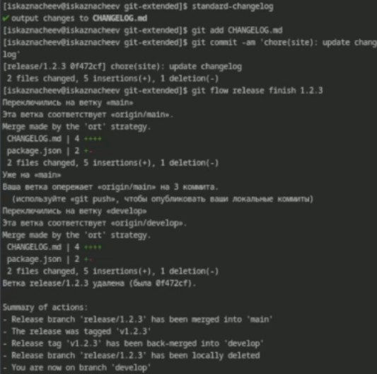

sc27

## Работа с релизами

Загрузим изменения на гитхаб и создадим релиз

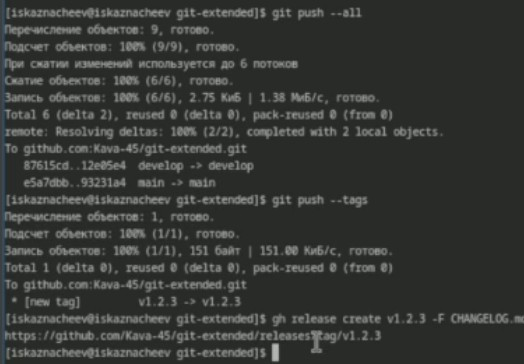

sc28

## Вывод

Я получил правильные навыки работы, с репозиториями git